# Assignment 10: Predictive Modeling - Part 1

*How to do it?*:

- Open the Rmarkdown file of this assignment (link) in Rstudio.
- Right under each **question**, insert a code chunk (you can use the hotkey `Ctrl + Alt + I` to add a code chunk) and code the solution for the question.
- `Knit` the rmarkdown file (hotkey: `Ctrl + Alt + K`) to export an html.
- Publish the html file to your Githiub Page.

*Submission*: Submit the link on Github of the assignment to Canvas

1. Use the `Adult Census Income` dataset. We will predict the income (whether or not it is more than 50k or not) of an adult. Import the dataset. Partition the data into 80% training and 20% testing.

```r
library(tidyverse)
df <- read_csv('C:\\Users\\student\\OneDrive - Bryant University\\Documents\\R\\Math421\\adult_census.csv')
df$target <- ifelse(df$income<='<=50K',0,1)

library(caret)
set.seed(2020)
splitIndex <- createDataPartition(df$target, p = .80,
                                  list = FALSE)
df_train <- df[ splitIndex,]
df_test <- df[-splitIndex,]
```

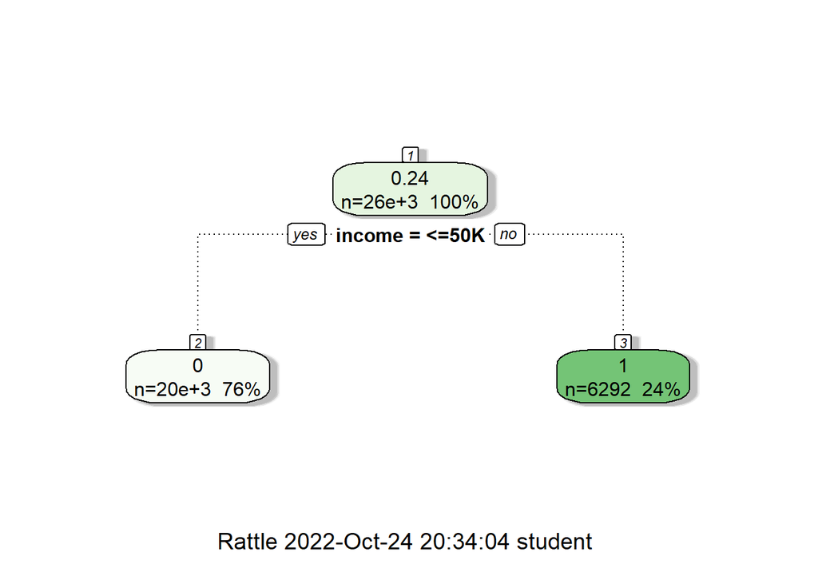

```r
library(rpart)
tree_model <- rpart(target ~ ., data = df_train,
                 control = rpart.control(maxdepth = 3))
library(rattle)
fancyRpartPlot(tree_model)
```

```r
tree_model$variable.importance
```

```
##        income  capital.gain     education education.num  capital.loss
##    4772.20024     868.43123     409.56582     409.56582     260.15014
##     workclass
##      67.50251
```

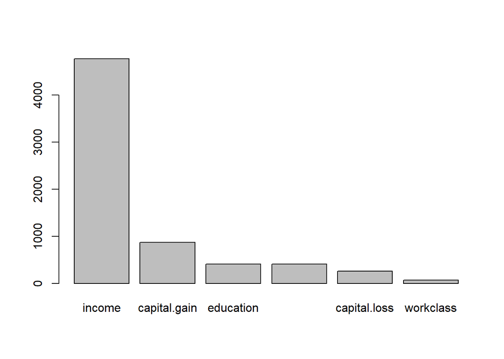

```r
barplot(tree_model$variable.importance)
```

3. Create 3 more trees and compare the testing accuracy of these trees, which tree give the highest testing accuracy.

```r
tree_model1 <- rpart(target ~ ., data = df_train,
                    control = rpart.control(maxdepth = 1))
pred1 <- predict(tree_model1, df_test, type = "class")
cm1 <- confusionMatrix(data = pred1, reference = df_test$target, positive = '1')

tree_model2 <- rpart(target ~ ., data = df_train,
                    control = rpart.control(maxdepth = 2))
pred2 <- predict(tree_model2, df_test, type = "class")
cm2 <- confusionMatrix(data = pred2, reference = df_test$target, positive = "1")

tree_model3 <- rpart(target ~ ., data = df_train,
                    control = rpart.control(maxdepth = 4))
pred3 <- predict(tree_model3, df_test, type = "class")
cm3 <- confusionMatrix(data = pred3, reference = df_test$target, positive = "1")

cm1$overall[1]
cm2$overall[1]
cm3$overall[1]
```

[output not shown]

```r
library(randomForest)
forest_model = randomForest(target ~ ., data=df_train, ntree = 1000)
predF <- predict(forest_model, df_test, type = "class")
cmF <- confusionMatrix(data = predF, reference = df_test$target)
cmF$overall[1]
```

[output not shown]

5. Create 3 more forests and compare the testing accuracy of these forests, which forest give the highest testing accuracy.

```r
forest_model1 = randomForest(target ~ ., data=df_train, ntree = 500)
predF1 <- predict(forest_model1, df_test, type = "class")
cmF1 <- confusionMatrix(data = predF1, reference = df_test$target)

forest_model2 = randomForest(target ~ ., data=df_train, ntree = 1500)
predF2 <- predict(forest_model2, df_test, type = "class")
cmF2 <- confusionMatrix(data = predF2, reference = df_test$target)

forest_model3 = randomForest(target ~ ., data=df_train, ntree = 2000)
predF3 <- predict(forest_model3, df_test, type = "class")
cmF3 <- confusionMatrix(data = predF3, reference = df_test$target)

cmF1$overall[1]
cmF2$overall[1]
cmF3$overall[1]
```

[output not shown]

6. What is the best model (in term of testing accuracy) among all models (including trees and forests) you have trained?

```r
## Each of the forest models had the same accuracy. ##
```

[output not shown]